# Household Income and Expenditure Patterns in Bangladesh

Md Ariful Islam

2025-05-21

## 1 Executive Summary

This analysis explores household income and expenditure patterns in Bangladesh using a simulated dataset modeled after the Household Income and Expenditure Survey (HIES). The objective is to identify regional and demographic disparities, and model expenditure behavior using income and household characteristics.

```r
# Simulate data
set.seed(2025)
n <- 300
df <- tibble(
  region = sample(c("Dhaka", "Chattogram", "Rajshahi", "Sylhet"), n, replace = TRUE),
  urban_rural = sample(c("Urban", "Rural"), n, replace = TRUE),
  household_size = sample(2:9, n, replace = TRUE),
  income = round(rnorm(n, mean = 42000, sd = 9000)),
  expenditure = round(income * runif(n, 0.55, 0.85)),
  age_group = sample(c("18-25", "26-35", "36-45", "46-60", "60+"), n, replace = TRUE),
  education_level = sample(c("No formal education", "Primary", "Secondary", "Higher"), n, replace = TRUE),
  employment_status = sample(c("Employed", "Self-employed", "Unemployed"), n, replace = TRUE)
)

glimpse(df)
```

```
## Rows: 300
## Columns: 8
## $ region            <chr> "Dhaka", "Sylhet", "Sylhet", "Chattogram", "Dhaka", …
## $ urban_rural       <chr> "Rural", "Rural", "Urban", "Urban", "Urban", "Rural"…
## $ household_size    <int> 3, 8, 6, 4, 6, 4, 7, 6, 4, 7, 4, 4, 3, 4, 7, 2, 5, 5…
## $ income            <dbl> 34798, 44608, 32457, 48654, 44382, 43215, 31270, 419…
## $ expenditure       <dbl> 24385, 37044, 24393, 28847, 28737, 24034, 25482, 301…
## $ age_group         <chr> "60+", "18-25", "18-25", "18-25", "60+", "60+", "18-…
## $ education_level   <chr> "Secondary", "Secondary", "No formal education", "Hi…
## $ employment_status <chr> "Employed", "Self-employed", "Self-employed", "Unemp…
```

## 2 Data Preparation

This analysis explores household income and expenditure patterns in Bangladesh using a simulated dataset modeled after the Household Income and Expenditure Survey (HIES). The objective is to identify regional and demographic disparities, and model expenditure behavior using income and household characteristics.

```r
df_summary <- df %>%
  group_by(region, urban_rural) %>%
  summarise(
    mean_income = round(mean(income), 1),
    mean_expenditure = round(mean(expenditure), 1),
    mean_household_size = round(mean(household_size), 1),
    .groups = "drop"
  )

kable(df_summary, caption = "Table 1: Summary by Region and Urban/Rural") %>%
  kable_styling(full_width = FALSE, bootstrap_options = c("striped", "hover"))
```

Table 1: Summary by Region and Urban/Rural

| region | urban_rural | mean_income | mean_expenditure | mean_household_size |
| --- | --- | --- | --- | --- |
| Chattogram | Rural | 41039.9 | 29080.0 | 5.1 |
| Chattogram | Urban | 42374.5 | 29932.0 | 5.7 |
| Dhaka | Rural | 37661.8 | 25677.3 | 5.5 |
| Dhaka | Urban | 44208.8 | 30352.0 | 5.9 |
| Rajshahi | Rural | 42171.5 | 28710.8 | 5.8 |
| Rajshahi | Urban | 45812.1 | 32394.6 | 5.1 |
| Sylhet | Rural | 40498.8 | 29497.2 | 5.5 |
| Sylhet | Urban | 42012.3 | 29567.7 | 5.6 |

## 3 Descriptive Statistics

We begin by summarizing the dataset using basic descriptive statistics, followed by grouped summaries by region and urban/rural classification.

### 3.1 Univariate Analysis

```r
library(gtsummary)

# Select relevant variables for analysis
df %>%
  select(region,urban_rural, age_group, employment_status, income, expenditure, household_size, employment_status) %>%
  tbl_summary(
    statistic = all_continuous() ~ "{mean} (SD: {sd}; Min: {min}; Max: {max})",
    digits = all_continuous() ~ 1,
    missing = "no"
  ) %>%
  modify_header(label = "**Variable**") %>%
  modify_caption("**Table 1: Univariate Summary Statistics**")
```

**Table 1: Univariate Summary Statistics**

| **Variable** | **N = 300**<sup>1</sup> |
| --- | --- |
| region |  |
| Chattogram | 75 (25%) |
| Dhaka | 60 (20%) |
| Rajshahi | 75 (25%) |
| Sylhet | 90 (30%) |
| urban_rural |  |
| Rural | 143 (48%) |
| Urban | 157 (52%) |
| age_group |  |
| 18-25 | 60 (20%) |
| 26-35 | 57 (19%) |
| 36-45 | 53 (18%) |
| 46-60 | 63 (21%) |
| 60+ | 67 (22%) |
| employment_status |  |
| Employed | 96 (32%) |
| Self-employed | 100 (33%) |
| Unemployed | 104 (35%) |
| income | 42,145.4 (SD: 9,626.1; Min: 15,750.0; Max: 71,437.0) |
| expenditure | 29,622.5 (SD: 7,894.6; Min: 9,535.0; Max: 55,152.0) |
| household_size |  |
| 2 | 38 (13%) |
| 3 | 38 (13%) |
| 4 | 36 (12%) |
| 5 | 42 (14%) |
| 6 | 29 (9.7%) |
| 7 | 46 (15%) |
| 8 | 30 (10%) |
| 9 | 41 (14%) |

<sup>1</sup> n (%); Mean (SD: SD; Min: Min; Max: Max)

### 3.2 Bivariate Analysis by Urban/Rural

```r
# Bivariate summary stratified by urban_rural
df %>%
  select(region,urban_rural, age_group, employment_status, income, expenditure, household_size, employment_status) %>%
  tbl_summary(
    by = urban_rural,
    statistic = all_continuous() ~ "{mean} (SD: {sd})",
    digits = all_continuous() ~ 1,
    missing = "no"
  ) %>%
  add_p() %>%
  modify_header(label = "**Variable**") %>%
  modify_caption("**Table 2: Bivariate Summary by Urban/Rural**")
```

**Table 2: Bivariate Summary by Urban/Rural**

| **Variable** | **Rural** N = 143<sup>1</sup> | **Urban** N = 157<sup>1</sup> | **p-value**<sup>2</sup> |
| --- | --- | --- | --- |
| region |  |  | 0.070 |
| Chattogram | 44 (31%) | 31 (20%) |  |
| Dhaka | 27 (19%) | 33 (21%) |  |
| Rajshahi | 28 (20%) | 47 (30%) |  |
| Sylhet | 44 (31%) | 46 (29%) |  |
| age_group |  |  | 0.4 |
| 18-25 | 31 (22%) | 29 (18%) |  |
| 26-35 | 26 (18%) | 31 (20%) |  |
| 36-45 | 29 (20%) | 24 (15%) |  |
| 46-60 | 24 (17%) | 39 (25%) |  |
| 60+ | 33 (23%) | 34 (22%) |  |
| employment_status |  |  | 0.4 |
| Employed | 43 (30%) | 53 (34%) |  |
| Self-employed | 53 (37%) | 47 (30%) |  |
| Unemployed | 47 (33%) | 57 (36%) |  |
| income | 40,457.1 (SD: 9,747.9) | 43,683.0 (SD: 9,279.9) | 0.014 |
| expenditure | 28,493.6 (SD: 7,990.1) | 30,650.8 (SD: 7,688.3) | 0.039 |
| household_size |  |  | 0.2 |
| 2 | 15 (10%) | 23 (15%) |  |
| 3 | 22 (15%) | 16 (10%) |  |
| 4 | 16 (11%) | 20 (13%) |  |
| 5 | 25 (17%) | 17 (11%) |  |
| 6 | 9 (6.3%) | 20 (13%) |  |
| 7 | 23 (16%) | 23 (15%) |  |
| 8 | 16 (11%) | 14 (8.9%) |  |
| 9 | 17 (12%) | 24 (15%) |  |

<sup>1</sup> n (%); Mean (SD: SD)  
<sup>2</sup> Pearson’s Chi-squared test; Wilcoxon rank sum test

## 4 Visual Analysis

### 4.1 Income vs Expenditure by Region

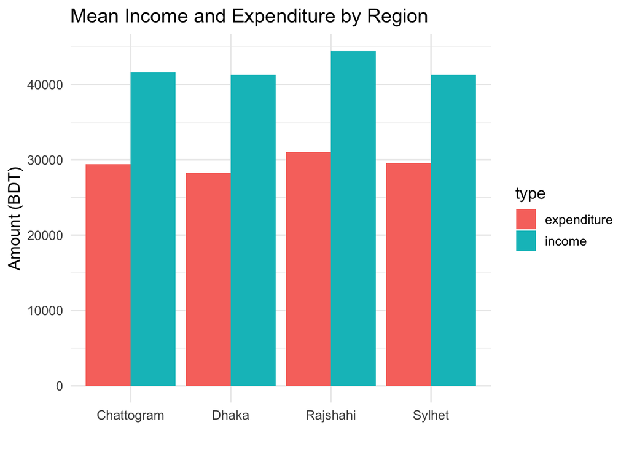

```r
df %>%
  pivot_longer(cols = c(income, expenditure), names_to = "type", values_to = "amount") %>%
  group_by(region, type) %>%
  summarise(mean_amount = mean(amount), .groups = "drop") %>%
  ggplot(aes(x = region, y = mean_amount, fill = type)) +
  geom_col(position = "dodge") +
  labs(title = "Mean Income and Expenditure by Region", y = "Amount (BDT)", x = "") +
  theme_minimal(base_size = 13)
```

### 4.2 Urban vs Rural Expenditure Comparison

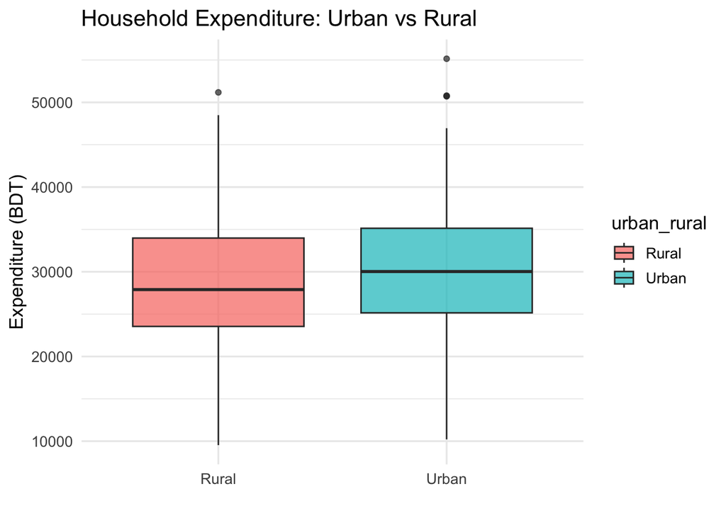

```r
df %>%
  ggplot(aes(x = urban_rural, y = expenditure, fill = urban_rural)) +
  geom_boxplot(alpha = 0.7) +
  labs(title = "Household Expenditure: Urban vs Rural",
       y = "Expenditure (BDT)", x = "") +
  theme_minimal(base_size = 13)
```

## 5 Regression Analysis

We model household expenditure as a function of income, region, urban/rural status, and household size:

```r
model <- lm(expenditure ~ income + household_size + region + urban_rural, data = df)
tidy(model) %>%
  kable(caption = "Table 2: Regression Results") %>%
  kable_styling(full_width = FALSE, bootstrap_options = c("striped", "hover"))
```

Table 2: Regression Results

| term | estimate | std.error | statistic | p.value |
| --- | --- | --- | --- | --- |
| (Intercept) | -864.9360820 | 1107.5527559 | -0.7809435 | 0.4354662 |
| income | 0.7335092 | 0.0221106 | 33.1745624 | 0.0000000 |
| household_size | -28.9681879 | 90.3280938 | -0.3206996 | 0.7486666 |
| regionDhaka | -914.4426879 | 627.1294158 | -1.4581403 | 0.1458729 |
| regionRajshahi | -484.6714262 | 596.7314818 | -0.8122103 | 0.4173304 |
| regionSylhet | 353.0365021 | 564.6917609 | 0.6251844 | 0.5323366 |
| urban_ruralUrban | -132.1890296 | 426.3645141 | -0.3100376 | 0.7567528 |

## 6 Decision Tree Model Analysis

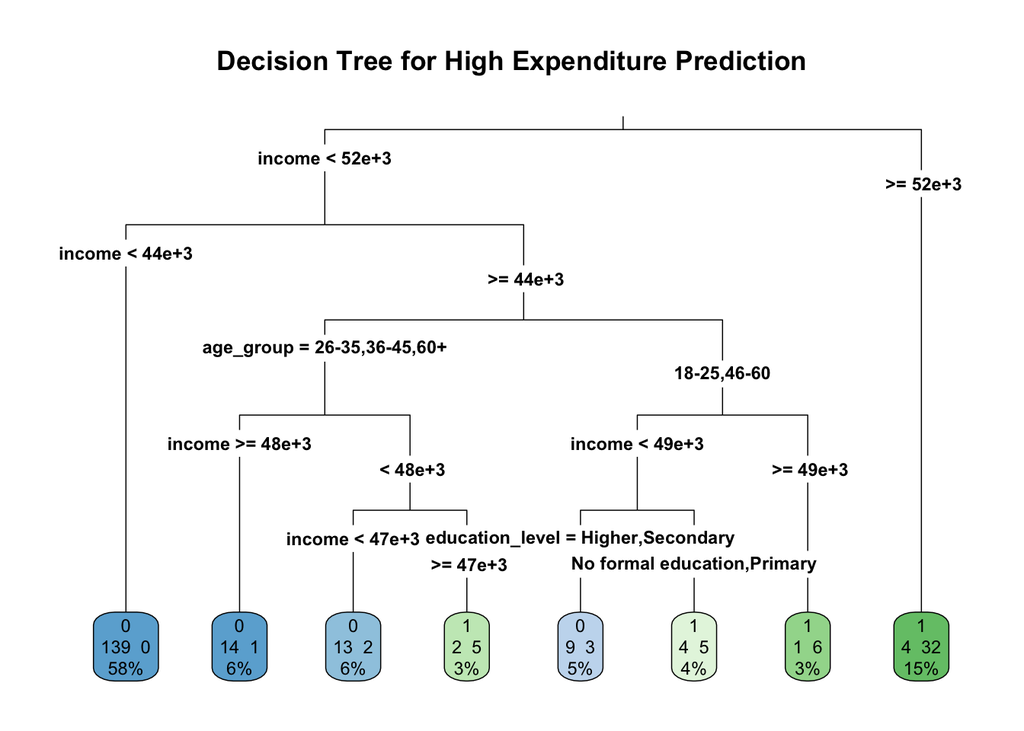

```r
# Create a new variable to predict: High expenditure (1 if expenditure > 35000, else 0)
df$high_expenditure <- ifelse(df$expenditure > 35000, 1, 0)

trainIndex <- createDataPartition(df$high_expenditure, p = 0.8, list = FALSE)
trainData <- df[trainIndex, ]
testData <- df[-trainIndex, ]

# Build the decision tree model
tree_model <- rpart(high_expenditure ~ region + urban_rural + household_size + income + age_group + education_level + employment_status,
                    data = trainData, method = "class")


# Improved visualization using rpart.plot
rpart.plot(tree_model, type = 3, extra = 101, fallen.leaves = TRUE, main = "Decision Tree for High Expenditure Prediction")
```

```r
# Make predictions on the test set
predictions <- predict(tree_model, testData, type = "class")

# Evaluate the model performance
conf_matrix <- confusionMatrix(predictions, as.factor(testData$high_expenditure))
print(conf_matrix)
```

```
## Confusion Matrix and Statistics
##
##           Reference
## Prediction  0  1
##          0 39  6
##          1  4 11
##
##                Accuracy : 0.8333
##                  95% CI : (0.7148, 0.9171)
##     No Information Rate : 0.7167
##     P-Value [Acc > NIR] : 0.02687
##
##                   Kappa : 0.5745
##
##  Mcnemar's Test P-Value : 0.75183
##
##             Sensitivity : 0.9070
##             Specificity : 0.6471
##          Pos Pred Value : 0.8667
##          Neg Pred Value : 0.7333
##              Prevalence : 0.7167
##          Detection Rate : 0.6500
##    Detection Prevalence : 0.7500
##       Balanced Accuracy : 0.7770
##
##        'Positive' Class : 0
##
```

## 7 Random Forest Model Analysis

```r
# Target variable
df$high_expenditure <- as.factor(ifelse(df$expenditure > 35000, 1, 0))  # classification target

trainIndex <- caret::createDataPartition(df$high_expenditure, p = 0.8, list = FALSE)
trainData <- df[trainIndex, ]
testData <- df[-trainIndex, ]

# Fit Random Forest model
rf_model <- randomForest(
  high_expenditure ~ region + urban_rural + household_size + income +
    age_group + education_level + employment_status,
  data = trainData,
  importance = TRUE,
  ntree = 500
)


# Make predictions
rf_predictions <- predict(rf_model, testData)

# Confusion Matrix
rf_conf_matrix <- caret::confusionMatrix(rf_predictions, testData$high_expenditure)
print(rf_conf_matrix)
```

```
## Confusion Matrix and Statistics
##
##           Reference
## Prediction  0  1
##          0 40  6
##          1  5  8
##
##                Accuracy : 0.8136
##                  95% CI : (0.6909, 0.9031)
##     No Information Rate : 0.7627
##     P-Value [Acc > NIR] : 0.2256
##
##                   Kappa : 0.4719
##
##  Mcnemar's Test P-Value : 1.0000
##
##             Sensitivity : 0.8889
##             Specificity : 0.5714
##          Pos Pred Value : 0.8696
##          Neg Pred Value : 0.6154
##              Prevalence : 0.7627
##          Detection Rate : 0.6780
##    Detection Prevalence : 0.7797
##       Balanced Accuracy : 0.7302
##
##        'Positive' Class : 0
##
```

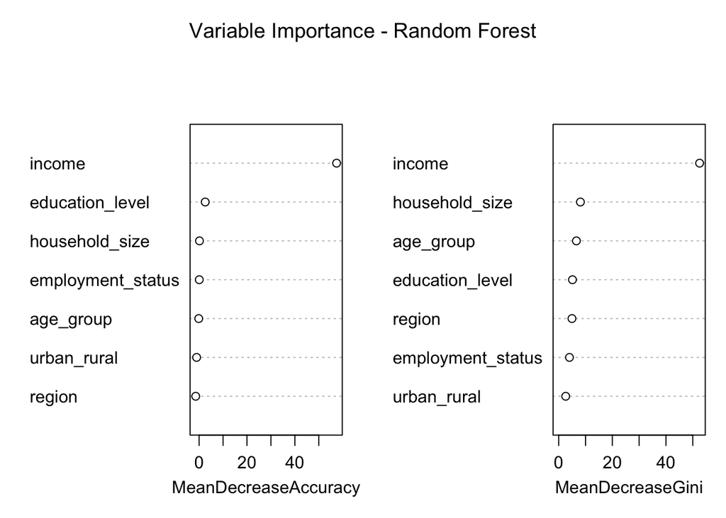

```r
# Variable Importance Plot
varImpPlot(rf_model, main = "Variable Importance - Random Forest")
```

## 8 ROC curve

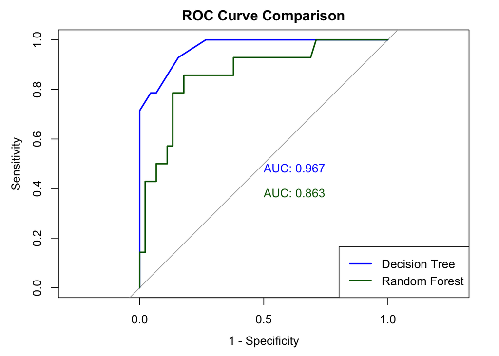

```r
# Decision Tree

tree_probs <- predict(tree_model, testData, type = "prob")[,2]  # Probabilities for class 1

# Random Forest

rf_probs <- predict(rf_model, testData, type = "prob")[,2]  # Probabilities for class 1

# Create ROC objects
roc_tree <- roc(testData$high_expenditure, tree_probs)
roc_rf <- roc(testData$high_expenditure, rf_probs)

# Plot
plot(roc_tree, col = "blue", main = "ROC Curve Comparison", print.auc = TRUE, legacy.axes = TRUE)
plot(roc_rf, col = "darkgreen", add = TRUE, print.auc = TRUE, print.auc.y = 0.4)
legend("bottomright", legend = c("Decision Tree", "Random Forest"),
       col = c("blue", "darkgreen"), lwd = 2)
```